# Lecture 7: Model Checking in the Cox Model II and a Complete Analysis

STA310 Survival Analysis · Collett Chapter 4 (part 2)

2026-10-06

## Today

1. Recap of lecture 6
2. Influential observations
3. Functional form of continuous covariates
4. Transformations
5. Validation of a Cox model
6. **A complete worked analysis** (PBC data)
7. Exercise and take-home

**Learning goals**

You can

- quantify the influence of one patient on a coefficient (`dfbeta`)
- check and model non-linear effects (splines, log transform) and test non-linearity
- explain concordance and optimism-corrected validation
- carry out and report a full Cox analysis as a workflow

## Recap: lecture 6

- Residuals for the Cox model: Cox–Snell (overall fit), martingale and deviance (outliers, form), Schoenfeld (PH)
- PH assumption: $h(t \mid x) = h_0(t)\exp(\beta' x)$, checked with log-minus-log plots and `cox.zph()`

Today we finish Chapter 4 with three more questions:

1. Is **one patient** driving the result? (influence)
2. Is a continuous covariate really **linear on the log-hazard scale**? (functional form)
3. Would the model **predict well** in new patients? (validation)

Then we put lectures 4-7 together in one analysis.

# Influential observations

## Why influence?

A fitted model can look fine overall and still depend on a few patients.

- An observation is **influential** if removing it changes $\hat\beta$ noticeably
- Typically: extreme covariate value (leverage) **and** an event much earlier or later than the model expects (large residual)
- Small samples and rare events are most vulnerable

Goal: not to delete “bad” patients, but to **know how fragile** the conclusions are.

## Influence on a coefficient: `dfbeta`

Let $\hat\beta_{(-i)}$ be the estimate when patient $i$ is left out. Then

$$\texttt{dfbeta}_{ij} \approx \hat\beta_j - \hat\beta_{j(-i)}$$

- Collett uses an approximation based on **score residuals** (one-step), so no refitting is needed: $\Delta_i\hat\beta \approx \text{(score residuals)}_i \cdot \widehat{\text{var}}(\hat\beta)$
- `dfbetas` = `dfbeta` divided by the standard error of $\hat\beta_j$: the shift in **standard-error units**
- Rule of thumb: look at observations that stand out; $|\texttt{dfbetas}| > 2/\sqrt{n}$ is a common (crude) flag

```r
residuals(fit, type = "dfbeta")    # n x p matrix
residuals(fit, type = "dfbetas")   # scaled by se
residuals(fit, type = "score")     # score residuals
```

## Example: multiple myeloma

48 patients, survival in months. Covariates: age, sex, `bun` (blood urea nitrogen), `ca`, `hb`, `pcells`, `protein`.

```r
fit_my <- coxph(Surv(time, status) ~ age + sex + bun + ca + hb + pcells + protein,
                data = myeloma)
broom::tidy(fit_my, exponentiate = TRUE, conf.int = TRUE) |>
  select(term, HR = estimate, conf.low, conf.high, p.value) |>
  mutate(across(where(is.numeric), \(x) round(x, 3)))
```

```
# A tibble: 7 × 5
  term       HR conf.low conf.high p.value
  <chr>   <dbl>    <dbl>     <dbl>   <dbl>
1 age     0.982    0.93       1.04   0.517
2 sex     0.779    0.354      1.72   0.536
3 bun     1.02     1.01       1.03   0
4 ca      1.01     0.781      1.31   0.92
5 hb      0.875    0.765      1.00   0.052
6 pcells  0.999    0.986      1.01   0.837
7 protein 0.505    0.218      1.17   0.112
```

Is any coefficient driven by single patients?

## `dfbeta` plot by patient

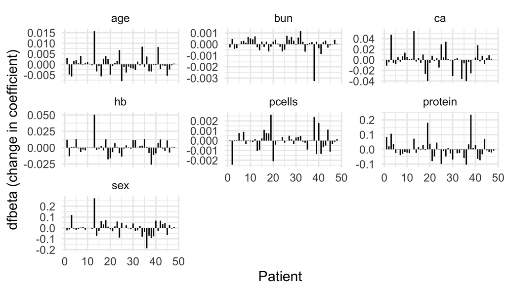

```r
db <- residuals(fit_my, type = "dfbeta")
colnames(db) <- names(coef(fit_my))
as_tibble(db) |>
  mutate(patient = myeloma$patient) |>
  pivot_longer(-patient, names_to = "term", values_to = "dfbeta") |>
  ggplot(aes(patient, dfbeta)) +
  geom_segment(aes(xend = patient, yend = 0)) +
  facet_wrap(~ term, scales = "free_y") +
  labs(x = "Patient", y = "dfbeta (change in coefficient)")
```

## Reading the plot and refitting

Largest scaled influence: patient 13 on hb (`dfbetas` = 0.73; crude flag $2/\sqrt{n}$ = 0.29).

Check by **refitting without** that patient:

```r
tibble(term = names(coef(fit_my)),
       `HR all` = exp(coef(fit_my)),
       `HR without` = exp(coef(fit_wo)),
       `p all` = summary(fit_my)$coef[, "Pr(>|z|)"],
       `p without` = summary(fit_wo)$coef[, "Pr(>|z|)"]) |>
  mutate(across(where(is.numeric), \(x) round(x, 3)))
```

```
# A tibble: 7 × 5
  term    `HR all` `HR without` `p all` `p without`
  <chr>      <dbl>        <dbl>   <dbl>       <dbl>
1 age        0.982        0.946   0.517       0.05
2 sex        0.779        0.371   0.536       0.042
3 bun        1.02         1.02    0           0
4 ca         1.01         0.869   0.92        0.338
5 hb         0.875        0.76    0.052       0.002
6 pcells     0.999        1.00    0.837       0.727
7 protein    0.505        0.411   0.112       0.044
```

Compare how the hazard ratio of hb moves, and whether any conclusion (direction, significance) changes.

## What to do with influential observations

1. **Check the data**: typing error? wrong unit? impossible value? Correct it if it is an error.
2. **Is the patient clinically different** (different population)? Document it.
3. **Refit without** and report both results: a **sensitivity analysis**.
4. If conclusions are unchanged: report the main analysis, mention the check.
5. If conclusions change: say so; do not hide it. Consider whether the model (functional form, missing covariate) is wrong.

**Warning**

Do not delete observations only because they are influential, and do not choose the analysis giving the “best” p-value.

## Leverage and other diagnostics (briefly)

- **Leverage**: observations far from the covariate mean; large `dfbeta` with a small residual usually means high leverage
- **Likelihood displacement** (Collett 4.3.2): influence on the **whole** set of estimates, based on score residuals
- **Deviance residuals** (lecture 6) show poorly fitted patients; `dfbeta` shows patients that move the fit

A patient can be an outlier without being influential, and vice versa. Always look at both.

# Functional form

## The assumption of linearity

For a continuous $x$ the Cox model assumes

$$\log h(t \mid x) = \log h_0(t) + \beta x$$

A one-unit increase has the **same** hazard ratio everywhere on the scale. For many lab values (bilirubin, creatinine, PSA) that is implausible: effects are often multiplicative, and the distribution is skewed.

Approaches (Collett 4.2.3):

1. Plot **martingale residuals of the null model** against $x$, add a smoother
2. Fit a more flexible form: transformation, quadratic, spline
3. Compare nested models with a **likelihood-ratio test**

## The PBC data used from here on

Mayo Clinic randomised trial of D-penicillamine vs placebo in primary biliary cirrhosis (1974-84). `survival::pbc`.

- Time in days; `status`: 0 = censored, 1 = **transplant**, 2 = **dead**
- We study **death**; transplanted patients are **censored at transplant** (more in the workflow)
- Randomised patients: 312; complete cases for the variables we use: 312

```r
cc |> select(years, death, trt, age, sex, edema, bili, albumin, stage) |> head(4)
```

```
      years death             trt      age    sex              edema bili
1  1.095140     1 D-penicillamine 58.76523 Female  Despite diuretics 14.5
2 12.320329     0 D-penicillamine 56.44627 Female               None  1.1
3  2.770705     1 D-penicillamine 70.07255   Male Untreated/resolved  1.4
4  5.270363     1 D-penicillamine 54.74059 Female Untreated/resolved  1.8
  albumin stage
1    2.60     4
2    4.14     3
3    3.48     4
4    2.54     4
```

## Step 1: martingale residuals from the null model

Recall lecture 6 (`bun` in the myeloma data): fit a model **without** the covariate (and with the others you want to adjust for), then plot residuals against the covariate. There `bun` was skewed and a log scale was suggested; the same issue arises here for bilirubin.

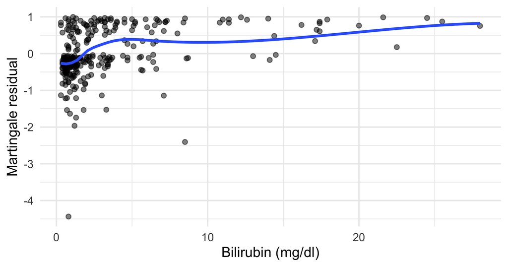

```r
fit0 <- coxph(Surv(years, death) ~ age + albumin + edema, data = cc)
cc$mart <- residuals(fit0, type = "martingale")
ggplot(cc, aes(bili, mart)) +
  geom_point(alpha = .5) +
  geom_smooth(method = "loess", formula = y ~ x, se = FALSE) +
  labs(x = "Bilirubin (mg/dl)", y = "Martingale residual")
```

The smooth curve estimates the **functional form** of $\log h$ in `bili`; but most points are squeezed at the left because of skewness.

## Same plot, on the log scale

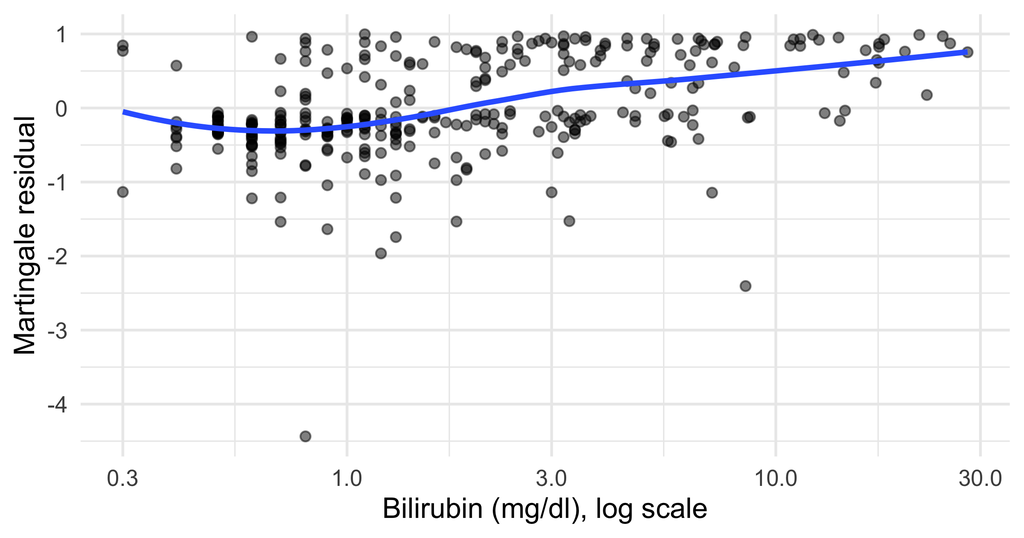

```r
ggplot(cc, aes(bili, mart)) +
  geom_point(alpha = .5) +
  geom_smooth(method = "loess", formula = y ~ x, se = FALSE) +
  scale_x_log10() +
  labs(x = "Bilirubin (mg/dl), log scale", y = "Martingale residual")
```

On the log scale the smooth is roughly **linear and increasing**: suggests $\log(\text{bili})$ is a natural scale. (Martingale residuals have a skewed distribution, so look at the trend, not single points.)

## Why transform? Skewed lab values

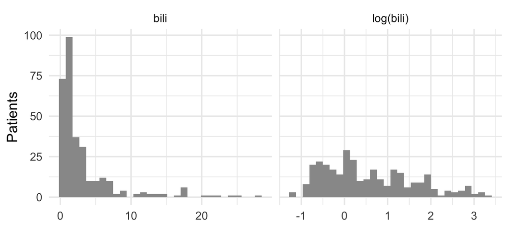

- Right-skewed biomarkers: a few large values get huge leverage and influence in a linear term
- $\log$: a **doubling** of bilirubin has one constant HR (interpretable: HR per doubling = $\exp(\beta \log 2)$, or use `log2(bili)`)
- Only for positive values; with zeros use $\log(x+c)$ with a justified $c$

## Option A: categorise (and why not as default)

```r
cc <- cc |> mutate(bili_cat = cut(bili, c(0, 1.1, 3, Inf), labels = c("<=1.1", "1.1-3", ">3")))
table(cc$bili_cat)
```

```
<=1.1 1.1-3    >3
  133    84    95
```

```r
coxph(Surv(years, death) ~ bili_cat + age + albumin + edema, data = cc) |>
  broom::tidy(exponentiate = TRUE, conf.int = TRUE) |>
  filter(str_detect(term, "bili")) |>
  select(term, HR = estimate, conf.low, conf.high) |>
  mutate(across(where(is.numeric), \(x) round(x, 2)))
```

```
# A tibble: 2 × 4
  term             HR conf.low conf.high
  <chr>         <dbl>    <dbl>     <dbl>
1 bili_cat1.1-3  2.47     1.44      4.25
2 bili_cat>3     7.85     4.66     13.2
```

Useful as a **diagnostic** (is the trend monotone?), but as the final model it has costs:

- **information loss** and loss of power; patients just either side of a cut-point are treated as different, those far apart within a group as equal
- cut-points are arbitrary (or data-driven, which inflates type I error)
- the step function is biologically implausible

## Option B: polynomial term

Add a quadratic term and test it with the likelihood-ratio test.

```r
f_lin  <- coxph(Surv(years, death) ~ log(bili) + age + albumin + edema, data = cc)
f_quad <- coxph(Surv(years, death) ~ log(bili) + I(log(bili)^2) + age + albumin + edema, data = cc)
anova(f_lin, f_quad)
```

```
Analysis of Deviance Table
 Cox model: response is  Surv(years, death)
 Model 1: ~ log(bili) + age + albumin + edema
 Model 2: ~ log(bili) + I(log(bili)^2) + age + albumin + edema
   loglik  Chisq Df Pr(>|Chi|)
1 -543.71
2 -543.05 1.3111  1     0.2522
```

Likelihood-ratio statistic $2(\ell_{quad} - \ell_{lin})$, compared to $\chi^2_1$. A small p-value would mean curvature on the log scale. Polynomials can behave badly at the ends of the range, which motivates splines.

## Option C: splines

A **spline** is a smooth piecewise polynomial; we let the data determine the shape with a few degrees of freedom (df).

```r
splines::ns(x, df = 3)       # natural cubic spline (linear in the tails)
rms::rcs(x, 4)               # restricted cubic spline, 4 knots (3 df)
survival::pspline(x, df = 4) # penalised spline, plots with termplot()
```

- `ns()` and `rcs()`: **parametric** (a few coefficients); fit in `coxph()`
- Individual spline coefficients are not interpretable: **plot the fitted curve** instead
- Choose few df (3-4); more df means more flexibility and more variance

## Spline fit for bilirubin

[figure not shown]

```r
f_ns <- coxph(Surv(years, death) ~ splines::ns(log(bili), df = 3) + age + albumin + edema, data = cc)
tp <- termplot(f_ns, term = 1, se = TRUE, plot = FALSE)[[1]]
ggplot(tp, aes(exp(x), y)) +
  geom_ribbon(aes(ymin = y - 1.96 * se, ymax = y + 1.96 * se), alpha = .25) +
  geom_line() + scale_x_log10() +
  labs(x = "Bilirubin (mg/dl), log scale", y = "Log hazard ratio (centred)")
```

## Likelihood-ratio test of non-linearity

The linear model is **nested** in the spline model: test $H_0$: effect of $\log(\text{bili})$ is linear.

```r
anova(f_lin, f_ns)
```

```
Analysis of Deviance Table
 Cox model: response is  Surv(years, death)
 Model 1: ~ log(bili) + age + albumin + edema
 Model 2: ~ splines::ns(log(bili), df = 3) + age + albumin + edema
   loglik  Chisq Df Pr(>|Chi|)
1 -543.71
2 -542.18 3.0636  2     0.2161
```

A non-significant LR test does not prove linearity (power!), but together with the plot it supports using $\log(\text{bili})$ **linearly**: simple and interpretable.

## Choosing among the options

| Approach | Pros | Cons |
| --- | --- | --- |
| Linear | simple, one HR | wrong if curved or skewed |
| Transform ($\log$) | simple, one HR, handles skew | needs justification |
| Categorise | easy to explain, diagnostic | information loss, arbitrary cut-points |
| Polynomial | easy to test | poor in tails |
| Spline (`ns`, `rcs`, `pspline`) | flexible | needs plot, df choice |

Also in practice: time origin matters too (e.g. diagnosis vs. study entry, age as time scale), but that is a design decision made before modelling.

# Validation

## Does the model predict well?

Fit statistics tell us the model describes **these** data. For a **prognostic** model we also ask how it performs in **new** patients.

- **Discrimination**: does the model rank patients correctly? Concordance (c-index)
- **Calibration**: do predicted survival probabilities agree with observed ones?
- **Overfitting**: apparent performance is optimistic, especially with many covariates and few events

## Concordance (c-index, Harrell’s C)

Among **comparable** pairs of patients (the one with shorter time had an event), the proportion where the patient with the higher linear predictor $\hat\eta_i = \hat\beta'x_i$ failed first.

- 0.5 = no better than chance; 1 = perfect ranking
- Accounts for censoring; depends on the censoring pattern, and measures only ranking, not calibration

```r
f_c <- coxph(Surv(years, death) ~ log(bili) + age + albumin + edema, data = cc)
concordance(f_c)
```

```
Call:
concordance.coxph(object = f_c)

n= 312
Concordance= 0.8392 se= 0.01949
concordant discordant     tied.x     tied.y    tied.xy
     20978       4019          0          3          0
```

The model ranks about 84% of comparable pairs correctly (apparent, i.e. in the same data used to fit).

## Calibration idea

Group patients by predicted risk (e.g. 4 groups at 3 years), compare mean **predicted** survival to **Kaplan–Meier** observed survival in each group.

- Good calibration: points on the diagonal
- A model can discriminate well but be badly calibrated (e.g. a different population)
- In R: `rms::calibrate()` (needs `cph(..., x = TRUE, y = TRUE, surv = TRUE, time.inc = )`), or `riskRegression::`/`pec::`

## Bootstrap optimism correction: `rms::validate`

Idea: refit on bootstrap samples, evaluate on the original data; the average drop estimates the **optimism**.

```r
dd <- rms::datadist(cc); options(datadist = "dd")
f_cph <- rms::cph(Surv(years, death) ~ log(bili) + age + albumin + edema, data = cc,
                  x = TRUE, y = TRUE)
v <- rms::validate(f_cph, B = 200)
v[c("Dxy", "R2"), c("index.orig", "optimism", "index.corrected")]
```

```
    index.orig    optimism index.corrected
Dxy  0.6784414 0.006063572       0.6723778
R2   0.4682029 0.017081655       0.4511212
```

`rms` reports Somers’ $D_{xy} = 2(C - 0.5)$. Apparent $C$ = 0.839, optimism-corrected $C$ = 0.836. Here the optimism is small: few variables relative to the number of events.

## Overfitting and events per variable

- The effective sample size in survival analysis is the **number of events**, not $n$
- Rule of thumb: **at least about 10 events per candidate parameter**, more is better (spline terms and dummy variables count)
- Number of events here: 125; parameters in the model: 5
- Variable selection (stepwise) **inside** the bootstrap too, otherwise optimism is underestimated
- Real external validation (other hospital, later period) is better than internal validation

**Note**

Internal validation by bootstrap estimates how well the **modelling procedure** would do in similar patients; it does not replace external validation.

# A complete Cox analysis

## The workflow

```
flowchart LR
  A[1 Question] --> B[2 Data and censoring]
  B --> C[3 KM and log-rank]
  C --> D[4 Univariable Cox]
  D --> E[5 Multivariable model]
  E --> F[6 Checks: PH, form, influence]
  F --> G[7 Final model]
  G --> H[8 Present results]
  H --> I[9 Interpret and limitations]
```

[output not shown]

We follow this recipe for the PBC trial. Each step uses a tool from lectures 2-7.

## 1. The question

Primary biliary cirrhosis: chronic liver disease, progressive, fatal without transplant.

- **Primary question**: does D-penicillamine prolong survival compared with placebo?
- **Secondary question**: which baseline characteristics are **prognostic** for death (adjusted for each other)?
- Event: **death from any cause**
- Time origin: randomisation. Time scale: years since randomisation.

**Note**

Writing the question and the estimand down first prevents data-driven analyses later. For a randomised trial, the treatment effect is the main target and the other covariates are for precision and prognosis.

## 2. Data, events and censoring

```r
pbc2 |> count(status = factor(status, 0:2, c("Censored (alive)", "Transplant", "Death")))
```

```
            status   n
1 Censored (alive) 168
2       Transplant  19
3            Death 125
```

- Death is the event. **Transplant**: a competing event that removes patients from risk of dying *untreated*. We **censor at transplant** (19 patients). This is acceptable only if transplant is unrelated to prognosis, which is **doubtful** (sicker patients get transplants first): informative censoring. The competing-risk analysis (later in the course) addresses this.
- Follow-up time is measured with the **reverse Kaplan–Meier** (event = censored):

```r
survfit(Surv(years, 1 - death) ~ 1, data = pbc2)
```

```
Call: survfit(formula = Surv(years, 1 - death) ~ 1, data = pbc2)

       n events median 0.95LCL 0.95UCL
[1,] 312    187   6.86    6.38     7.3
```

## Missing data, explicitly

```r
pbc2 |> select(trt, age, sex, edema, bili, albumin, protime, stage, copper) |>
  summarise(across(everything(), \(x) sum(is.na(x)))) |>
  pivot_longer(everything(), names_to = "variable", values_to = "n missing") |>
  filter(`n missing` > 0)
```

```
# A tibble: 1 × 2
  variable `n missing`
  <chr>          <int>
1 copper             2
```

## Baseline table

```r
cc |>
  select(trt, age, sex, edema, bili, albumin, protime, stage) |>
  mutate(stage = factor(stage)) |>
  gtsummary::tbl_summary(by = trt, statistic = list(gtsummary::all_continuous() ~ "{median} ({p25}, {p75})")) |>
  gtsummary::add_overall()
```

| **Characteristic** | **Overall** N = 312<sup>1</sup> | **Placebo** N = 154<sup>1</sup> | **D-penicillamine** N = 158<sup>1</sup> |
| --- | --- | --- | --- |
| age | 50 (42, 57) | 48 (41, 56) | 52 (43, 59) |
| sex |  |  |  |
| Male | 36 (12%) | 15 (9.7%) | 21 (13%) |
| Female | 276 (88%) | 139 (90%) | 137 (87%) |
| edema |  |  |  |
| None | 263 (84%) | 131 (85%) | 132 (84%) |
| Untreated/resolved | 29 (9.3%) | 13 (8.4%) | 16 (10%) |
| Despite diuretics | 20 (6.4%) | 10 (6.5%) | 10 (6.3%) |
| bili | 1.4 (0.8, 3.5) | 1.3 (0.7, 3.6) | 1.4 (0.8, 3.2) |
| albumin | 3.55 (3.31, 3.80) | 3.55 (3.34, 3.78) | 3.57 (3.21, 3.83) |
| protime | 10.60 (10.00, 11.10) | 10.60 (10.00, 11.40) | 10.60 (10.00, 11.00) |
| stage |  |  |  |
| 1 | 16 (5.1%) | 4 (2.6%) | 12 (7.6%) |
| 2 | 67 (21%) | 32 (21%) | 35 (22%) |
| 3 | 120 (38%) | 64 (42%) | 56 (35%) |
| 4 | 109 (35%) | 54 (35%) | 55 (35%) |

<sup>1</sup> Median (Q1, Q3); n (%)

Balanced between arms, as expected after randomisation. Bilirubin is skewed (median vs. quartiles).

## 3. Kaplan–Meier and log-rank

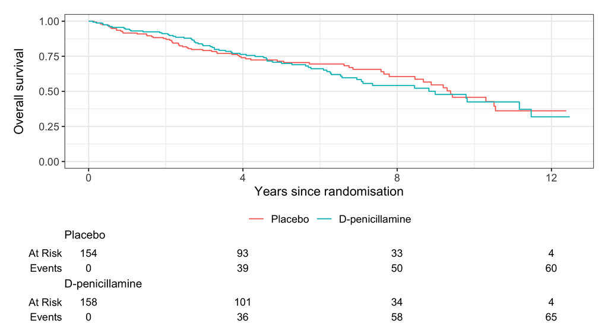

```r
survfit2(Surv(years, death) ~ trt, data = cc) |>
  ggsurvfit() + add_risktable() +
  labs(x = "Years since randomisation", y = "Overall survival") +
  scale_y_continuous(limits = c(0, 1))
```

```r
survdiff(Surv(years, death) ~ trt, data = cc)
```

```
Call:
survdiff(formula = Surv(years, death) ~ trt, data = cc)

                      N Observed Expected (O-E)^2/E (O-E)^2/V
trt=Placebo         154       60     61.8    0.0513     0.102
trt=D-penicillamine 158       65     63.2    0.0502     0.102

 Chisq= 0.1  on 1 degrees of freedom, p= 0.7
```

Log-rank p = 0.75: no evidence of a survival difference between arms, curves overlap.

## 4. Univariable Cox models

One covariate at a time: **screening**, and unadjusted HRs.

```r
uni <- function(f) {
  m <- coxph(as.formula(paste("Surv(years, death) ~", f)), data = cc |> mutate(stage = factor(stage)))
  broom::tidy(m, exponentiate = TRUE, conf.int = TRUE) |>
    transmute(model = f, term, HR = round(estimate, 2),
              lower = round(conf.low, 2), upper = round(conf.high, 2), p = signif(p.value, 2))
}
map_dfr(c("trt", "age", "sex", "edema", "log(bili)", "albumin", "log(protime)", "stage"), uni) |>
  select(-model)
```

```
# A tibble: 11 × 5
   term                        HR lower  upper        p
   <chr>                    <dbl> <dbl>  <dbl>    <dbl>
 1 trtD-penicillamine        1.06  0.75   1.5  7.5 e- 1
 2 age                       1.04  1.02   1.06 5.7 e- 6
 3 sexFemale                 0.62  0.39   0.98 4.1 e- 2
 4 edemaUntreated/resolved   2.39  1.42   4.02 1   e- 3
 5 edemaDespite diuretics   10.9   6.51  18.2  7.80e-20
 6 log(bili)                 2.96  2.47   3.55 3   e-31
 7 albumin                   0.17  0.11   0.25 9.90e-18
 8 log(protime)            176.   45.6  680.   6.5 e-14
 9 stage2                    4.99  0.66  37.6  1.2 e- 1
10 stage3                    8.58  1.18  62.4  3.4 e- 2
11 stage4                   21.4   2.96 154.   2.4 e- 3
```

Most prognostic variables are clearly associated with death; treatment is not. Univariable results are confounded by each other (e.g. bilirubin, albumin and stage all reflect disease severity); do not select variables **only** by univariable p-values.

## 5. Multivariable model

Covariates chosen **a priori** on clinical grounds (known prognostic factors), plus treatment. Initial functional forms: age per 10 years, $\log(\text{bili})$, $\log(\text{protime})$, albumin linear.

```r
cc <- cc |> mutate(stage_f = factor(stage), age10 = age / 10)
fit1 <- coxph(Surv(years, death) ~ trt + age10 + sex + edema + log(bili) + albumin +
                log(protime) + stage_f, data = cc)
broom::tidy(fit1, exponentiate = TRUE, conf.int = TRUE) |>
  select(term, HR = estimate, conf.low, conf.high, p.value) |>
  mutate(across(where(is.numeric), \(x) round(x, 3)))
```

```
# A tibble: 11 × 5
   term                        HR conf.low conf.high p.value
   <chr>                    <dbl>    <dbl>     <dbl>   <dbl>
 1 trtD-penicillamine       0.961    0.657      1.40   0.836
 2 age10                    1.31     1.09       1.58   0.004
 3 sexFemale                0.664    0.4        1.10   0.113
 4 edemaUntreated/resolved  1.20     0.677      2.11   0.54
 5 edemaDespite diuretics   2.52     1.37       4.63   0.003
 6 log(bili)                2.30     1.88       2.81   0
 7 albumin                  0.422    0.258      0.69   0.001
 8 log(protime)            22.6      2.04     251.     0.011
 9 stage_f2                 4.42     0.563     34.7    0.157
10 stage_f3                 5.29     0.705     39.6    0.105
11 stage_f4                 6.28     0.836     47.2    0.074
```

## 6a. Check proportional hazards

```r
zph <- cox.zph(fit1)
zph
```

```
              chisq df     p
trt           1.095  1 0.295
age10         0.203  1 0.653
sex           0.216  1 0.642
edema         5.568  2 0.062
log(bili)     0.666  1 0.414
albumin       0.602  1 0.438
log(protime)  5.156  1 0.023
stage_f       5.230  3 0.156
GLOBAL       15.849 11 0.147
```

- Smallest p-value among the covariates: log(protime) (p = 0.023); global test p = 0.15
- With 125 events even modest departures are detectable: look at the **plots** and size of the effect, not only p-values

## 6a. PH plots for the most suspicious terms

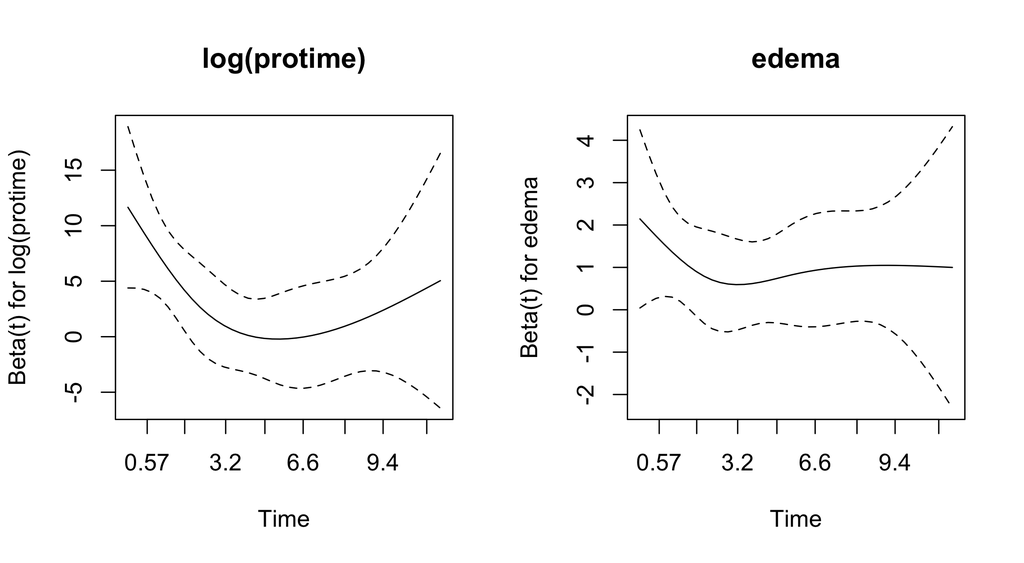

```r
par(mfrow = c(1, 2), cex = 1.1)
idx <- order(zt[-nrow(zt), "p"])[1:2]
for (i in idx) plot(zph[i], resid = FALSE, main = rownames(zt)[i])
```

If the smooth coefficient drifts with time the effect changes over follow-up. Options (lecture 6): stratify on the variable, add a time interaction, or report an average effect with a caveat. The suspicious variables are **nuisance adjustments**; the treatment term shows no sign of non-PH (see the table). We keep the model and note it as a limitation.

## 6b. Check functional form

[figure not shown]

```r
fit_nobili <- coxph(Surv(years, death) ~ trt + age10 + sex + edema + albumin + log(protime) + stage_f, data = cc)
cc$mart1 <- residuals(fit_nobili, type = "martingale")
ggplot(cc, aes(albumin, mart1)) + geom_point(alpha = .5) +
  geom_smooth(method = "loess", formula = y ~ x, se = FALSE) +
  labs(x = "Albumin (g/dl)", y = "Martingale residual (model without albumin)")
```

```r
f_sp <- coxph(Surv(years, death) ~ trt + age10 + sex + edema + splines::ns(albumin, 3) + log(bili) +
                log(protime) + stage_f, data = cc)
anova(fit1, f_sp)
```

```
Analysis of Deviance Table
 Cox model: response is  Surv(years, death)
 Model 1: ~ trt + age10 + sex + edema + log(bili) + albumin + log(protime) + stage_f
 Model 2: ~ trt + age10 + sex + edema + splines::ns(albumin, 3) + log(bili) + log(protime) + stage_f
   loglik  Chisq Df Pr(>|Chi|)
1 -535.84
2 -535.38 0.9128  2     0.6336
```

## 6c. Check influence

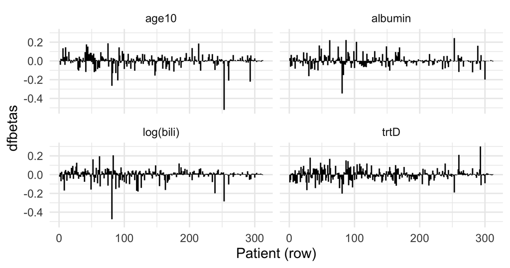

```r
dbs <- residuals(fit1, type = "dfbetas")
colnames(dbs) <- names(coef(fit1))
as_tibble(dbs) |> mutate(row = row_number()) |>
  select(row, trtD = `trtD-penicillamine`, `log(bili)`, albumin, age10) |>
  pivot_longer(-row, names_to = "term", values_to = "dfbetas") |>
  ggplot(aes(row, dfbetas)) + geom_segment(aes(xend = row, yend = 0)) +
  facet_wrap(~ term) + labs(x = "Patient (row)", y = "dfbetas")
```

Maximum $|\texttt{dfbetas}|$: treatment 0.3, $\log$(bili) 0.48, albumin 0.35. No single patient shifts a coefficient by more than a fraction of its standard error; we do not remove any patient.

## 7. Final model

Treatment is kept regardless of significance (randomised comparison). We test whether `log(protime)` is needed, to avoid noise variables.

```r
fit2 <- fit1   # final model
fit_np <- coxph(Surv(years, death) ~ trt + age10 + sex + edema + log(bili) + albumin + stage_f, data = cc)
anova(fit_np, fit2)
```

```
Analysis of Deviance Table
 Cox model: response is  Surv(years, death)
 Model 1: ~ trt + age10 + sex + edema + log(bili) + albumin + stage_f
 Model 2: ~ trt + age10 + sex + edema + log(bili) + albumin + log(protime) + stage_f
   loglik  Chisq Df Pr(>|Chi|)
1 -538.94
2 -535.84 6.1984  1    0.01279 *
---
Signif. codes:  0 '***' 0.001 '**' 0.01 '*' 0.05 '.' 0.1 ' ' 1
```

Adding `log(protime)`: LR p = 0.013, so we **keep** it, although it was also the weakest term in the PH check. The final model was chosen by clinical reasoning and checked; its apparent concordance is 0.854.

## Validate the final model

```r
f_fin_cph <- rms::cph(Surv(years, death) ~ trt + age10 + sex + edema + log(bili) + albumin + log(protime) + stage_f,
                      data = cc, x = TRUE, y = TRUE)
vf <- rms::validate(f_fin_cph, B = 200)
vf[c("Dxy", "R2"), c("index.orig", "optimism", "index.corrected")]
```

```
    index.orig   optimism index.corrected
Dxy  0.7080450 0.01966772       0.6883772
R2   0.4951925 0.04655415       0.4486383
```

Apparent $C$ = 0.854, corrected $C$ = 0.844; 125 events for 11 parameters, about 11.4 per parameter: acceptable.

## 8a. Table of hazard ratios

```r
gtsummary::tbl_regression(fit2, exponentiate = TRUE,
  label = list(age10 ~ "Age (per 10 years)", `log(bili)` ~ "log bilirubin",
               albumin ~ "Albumin (per g/dl)", `log(protime)` ~ "log prothrombin time", stage_f ~ "Histologic stage"))
```

| **Characteristic** | **HR** | **95% CI** | **p-value** |
| --- | --- | --- | --- |
| trt |  |  |  |
| Placebo | — | — |  |
| D-penicillamine | 0.96 | 0.66, 1.41 | 0.8 |
| Age (per 10 years) | 1.31 | 1.09, 1.58 | 0.004 |
| sex |  |  |  |
| Male | — | — |  |
| Female | 0.66 | 0.40, 1.10 | 0.11 |
| edema |  |  |  |
| None | — | — |  |
| Untreated/resolved | 1.19 | 0.68, 2.11 | 0.5 |
| Despite diuretics | 2.52 | 1.37, 4.63 | 0.003 |
| log bilirubin | 2.30 | 1.88, 2.81 | <0.001 |
| Albumin (per g/dl) | 0.42 | 0.26, 0.69 | <0.001 |
| log prothrombin time | 22.6 | 2.04, 251 | 0.011 |
| Histologic stage |  |  |  |
| 1 | — | — |  |
| 2 | 4.42 | 0.56, 34.7 | 0.2 |
| 3 | 5.29 | 0.71, 39.6 | 0.11 |
| 4 | 6.28 | 0.84, 47.2 | 0.074 |

Abbreviations: CI = Confidence Interval, HR = Hazard Ratio

## 8b. Forest plot

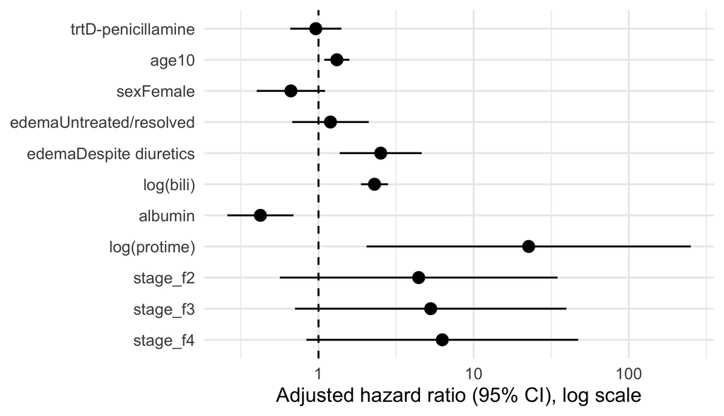

```r
broom::tidy(fit2, exponentiate = TRUE, conf.int = TRUE) |>
  mutate(term = fct_rev(fct_inorder(term))) |>
  ggplot(aes(estimate, term)) +
  geom_vline(xintercept = 1, linetype = 2) +
  geom_pointrange(aes(xmin = conf.low, xmax = conf.high)) +
  scale_x_log10() +
  labs(x = "Adjusted hazard ratio (95% CI), log scale", y = NULL)
```

## 8c. Adjusted survival curves

Predicted survival for typical patients (treatment arms; other covariates fixed), using the final model:

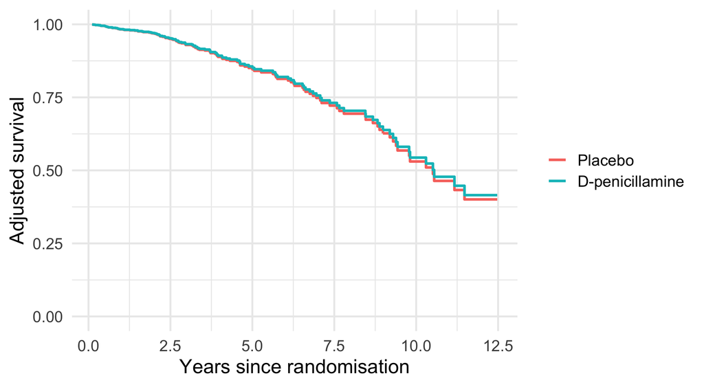

```r
nd <- tibble(trt = factor(c("Placebo", "D-penicillamine"), levels = levels(cc$trt)),
             age10 = median(cc$age10), sex = "Female", edema = "None",
             bili = median(cc$bili), albumin = median(cc$albumin),
             protime = median(cc$protime), stage_f = "3") |>
  mutate(sex = factor(sex, levels = levels(cc$sex)), edema = factor(edema, levels = levels(cc$edema)),
         stage_f = factor(stage_f, levels = levels(cc$stage_f)))
sf <- survfit(fit2, newdata = nd)
sf_df <- tibble(time = rep(sf$time, 2), surv = c(sf$surv), arm = rep(nd$trt, each = length(sf$time)))
ggplot(sf_df, aes(time, surv, colour = arm)) + geom_step(linewidth = 1) +
  scale_y_continuous(limits = c(0, 1)) +
  labs(x = "Years since randomisation", y = "Adjusted survival", colour = NULL)
```

Female, median age, bilirubin and albumin, no oedema, median prothrombin time, stage 3. The curves are **conditional** on these values; the PH model forces them apart by a constant HR.

## Another view: effect of bilirubin

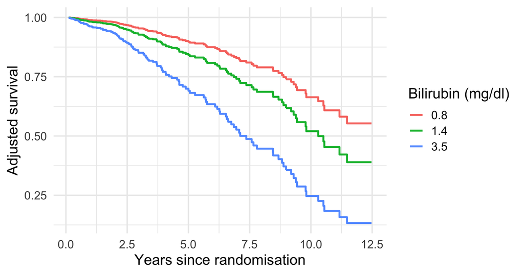

```r
nd2 <- tibble(trt = factor("Placebo", levels = levels(cc$trt)), age10 = median(cc$age10),
              sex = factor("Female", levels = levels(cc$sex)),
              edema = factor("None", levels = levels(cc$edema)),
              bili = c(0.8, 1.4, 3.5), albumin = median(cc$albumin), protime = median(cc$protime),
              stage_f = factor("3", levels = levels(cc$stage_f)))
s2 <- survfit(fit2, newdata = nd2)
tibble(time = rep(s2$time, 3), surv = c(s2$surv),
       bili = factor(rep(nd2$bili, each = length(s2$time)))) |>
  ggplot(aes(time, surv, colour = bili)) + geom_step(linewidth = 1) +
  labs(x = "Years since randomisation", y = "Adjusted survival", colour = "Bilirubin (mg/dl)")
```

## 9. Interpretation (draft of a results paragraph)

> Among 312 randomised patients with complete data, 125 died during follow-up. After adjustment for age, sex, oedema, bilirubin, albumin, prothrombin time and histologic stage, the hazard ratio for D-penicillamine versus placebo was 0.96 (95% CI 0.66 to 1.41), i.e. no evidence of a treatment effect on survival. Higher bilirubin was associated with higher mortality: the hazard ratio per doubling was 1.78. Each 1 g/dl higher albumin was associated with a hazard ratio of 0.42 (95% CI 0.26 to 0.69).

Note: HR of bilirubin per **doubling** = $\exp(\hat\beta \log 2)$, from the log-scale coefficient. HRs are **adjusted**, are relative (no absolute risk), and are **associations** for the prognostic factors, not causal effects.

# Wrap-up

## In-class exercise (15 min)

Use `survival::lung` (Stanford/NCCTG lung cancer; `status` 1 = censored, 2 = dead; `ph.karno`, `age`, `sex`, `wt.loss`).

1. Recode the event (`status == 2`), fit `Surv(time, event) ~ age + sex + ph.karno + wt.loss` on complete cases.
2. Compute `dfbetas`. Which patient has the largest influence on `wt.loss`? Refit without that patient and compare.
3. Plot martingale residuals from a model without `age` against `age`. Is a linear term reasonable? Test a spline term with a likelihood-ratio test.
4. Compute the concordance. Is it large or small? What does it not tell you?

*Discussion*: if one patient changes the HR from 1.10 (significant) to 1.05 (not significant), what do you report?

## Quiz

1. What does `dfbetas` $= -0.4$ for patient $i$ and covariate $j$ mean?
2. Why is categorising a continuous covariate a poor default?
3. A c-index of 0.75 says the model has good calibration. True or false?
4. In a data set with 40 events, how many parameters should a prognostic model contain, roughly?

## Take-home messages

- **Influence**: use `dfbeta`/`dfbetas`; refit without the patient and report a sensitivity analysis. Do not delete data silently.
- **Functional form**: martingale residual plot, then transformation ($\log$ for skewed labs) or splines; test non-linearity with a likelihood-ratio test. Avoid categorisation as default.
- **Validation**: concordance measures ranking; use bootstrap (`rms::validate`) for optimism; count **events** per parameter.
- **Workflow**: question, data/censoring/missing data, KM, univariable, multivariable, checks, final model, tables and figures, interpretation with limitations.
- Always describe what was done with censoring and missing data.

**Next lecture**: parametric survival models (Collett, Chapter 5).

**Reading**: Collett, Chapter 4 (4.2.3 functional form, 4.3 influential observations, 4.5 recommendations).